# Making Supply & Demand Curves using R + ggplot2

If you want change the titles of the axes or adjust the limits of the axes, you can do so by adjusting the values of the options of `scale_x_continuous` and `scale_y_continuous`:

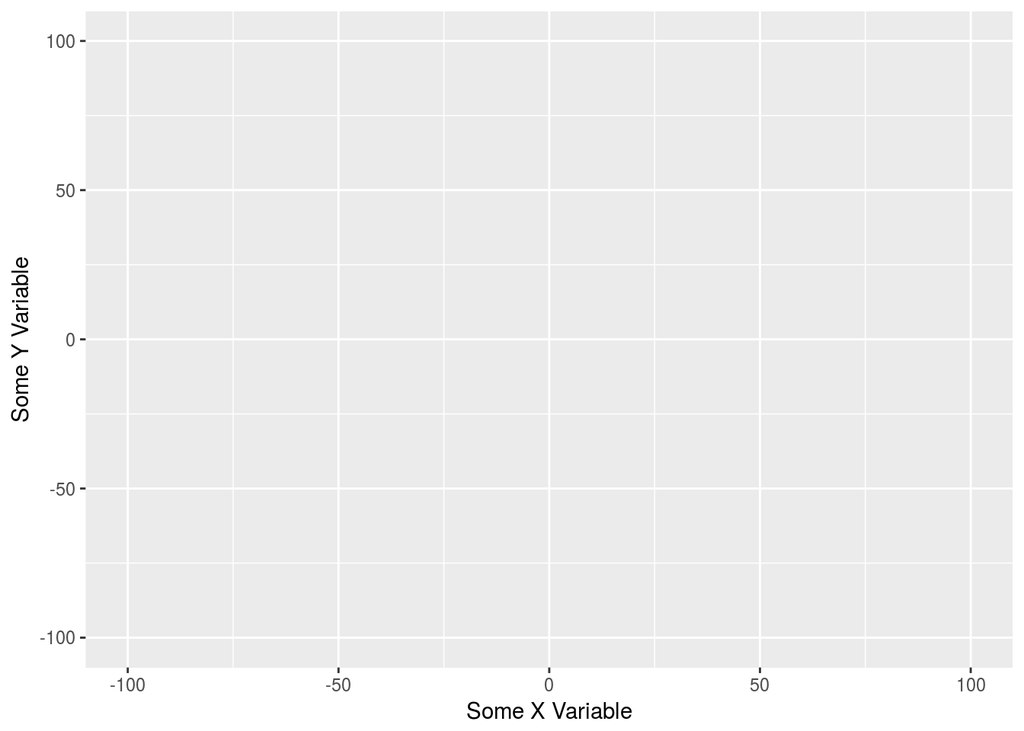

```r
ggplot()+
  scale_x_continuous(name = "Some X Variable", limits=c(-100,100)) +
  scale_y_continuous(name = "Some Y Variable", limits=c(-100,100))
```

There are other aesthetics that you can control. If you want to specify the increments of the axes, you can do that by specifying `breaks` option. For example, let’s say I want to specify that the X axis goes by increments of 10:

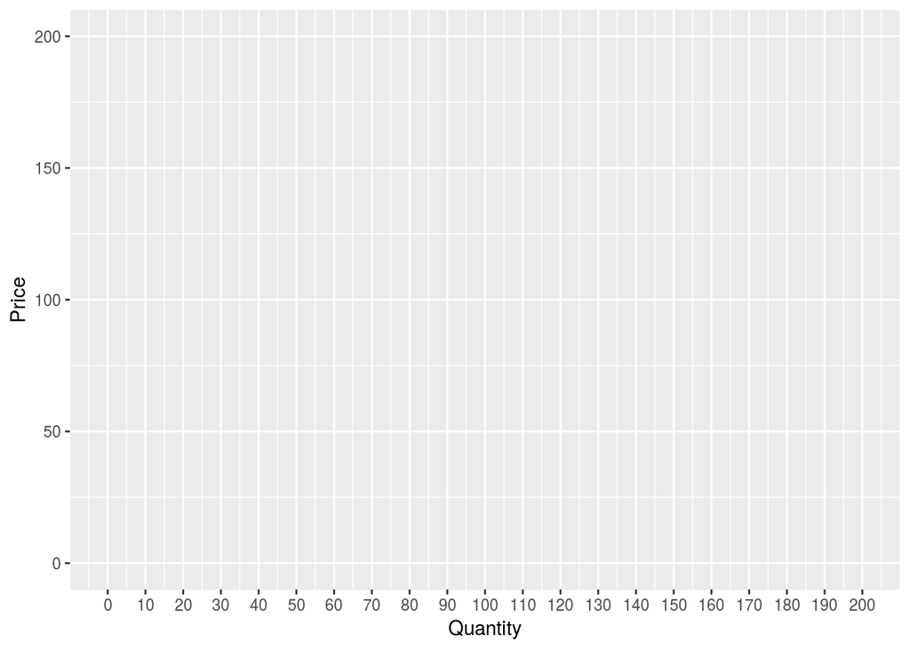

```r
ggplot()+
  scale_x_continuous(name = "Quantity", limits=c(0,200), breaks=seq(0,200,10)) +
  scale_y_continuous(name = "Price", limits=c(0,200))
```

You can write out the breaks option completely like this:

```
breaks=c(0,10, 20, 30, 40, 50, ... ,200)
```

But I use the `seq` function as a shortcut above, which produces a vector of numbers ranging from 0 to 200 in increments of 10.

For the purposes of this tutorial, I am okay with the default axis increments but I want three aesthetic adjustments:

1. A clean black and white look. I can get this by adding the `theme_bw()` layer. For aesthetic reasons, I want the default font size to be 8 within this theme.
2. I want to remove the grid lines inside the plot. I’ll use the `panel.grid` options inside of a theme layer.
3. Get rid of the “overhang” around the axes to make the axes cut off exactly and 0 and 200. I can get this by specifying the `expand` option within `scale_x_continuous` and `scale_y_continuous`.

All together, the base plot for these supply and demand graphics that I’ll use in this tutorial looks like this:

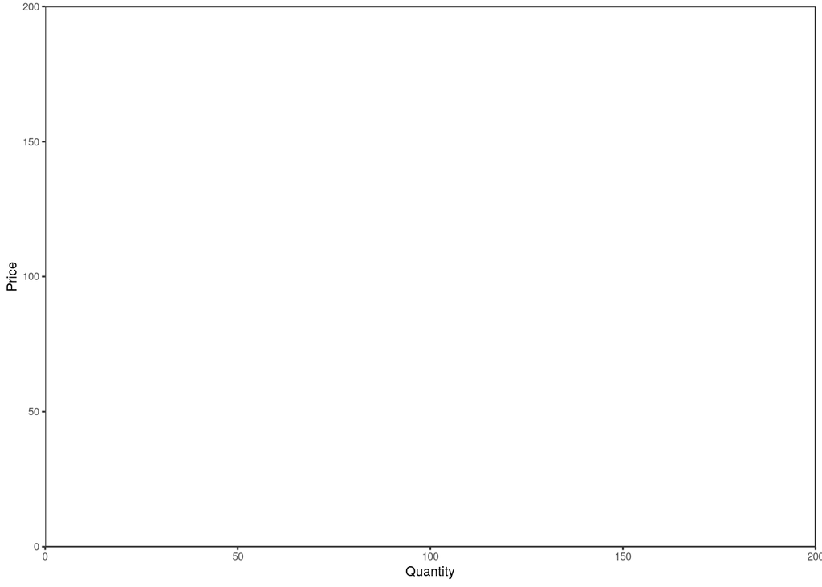

```r
ggplot()+ #set up plot space
  theme_bw(base_size=8)+ #black and white theme with default font size = 8
  theme(panel.grid.major = element_blank(), panel.grid.minor = element_blank())+ #remove grid lines
  scale_x_continuous(name = "Quantity", limits=c(0,200), expand=c(0,0)) +  #set up x-axis
  scale_y_continuous(name = "Price", limits=c(0,200), expand=c(0,0)) #set up y-axis
```

### Lines (Supply and Demand Curves)

This is the easier part. Once we have our plot background set, we just layer different types of plots (these are called `geoms` in ggplot speak) on top of our background. To draw lines where we have a defined intercept and slope, we use `geom_abline`. Let’s use the supply and demand curves from our last homework, re-arranged so that price is the “y” variable:

$$\begin{aligned}
P &= 175 - Q^D \\
P &= 100 + 2Q^S
\end{aligned}$$

`geom_abline` requires that we give it a value for `intercept` and `slope`, which we have from our equations. To add these lines, we simply layer them over our background.

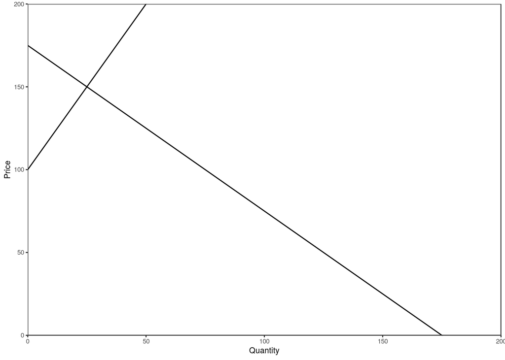

```r
ggplot()+ #set up plot space
  theme_bw(base_size=8)+ #black and white theme
  theme(panel.grid.major = element_blank(), panel.grid.minor = element_blank())+ #remove grid lines
  scale_x_continuous(name = "Quantity", limits=c(0,200), expand=c(0,0)) +  #set up x-axis
  scale_y_continuous(name = "Price", limits=c(0,200), expand=c(0,0))+ #set up y-axis
  geom_abline(slope = -1, intercept = 175)+ ## demand curve
  geom_abline(slope = 2, intercept = 100) ## supply curve
```

The basics of our plot are now in place. If we want to annotate the graphs, we can do so by adding in an `annotate` layer. The annotate layer will ask for the type of annotation you want (`text`), x and y coordinates, and what you want the annotation to say (`label`). You can also adjust the size of the annotation by specifying a `size` value.

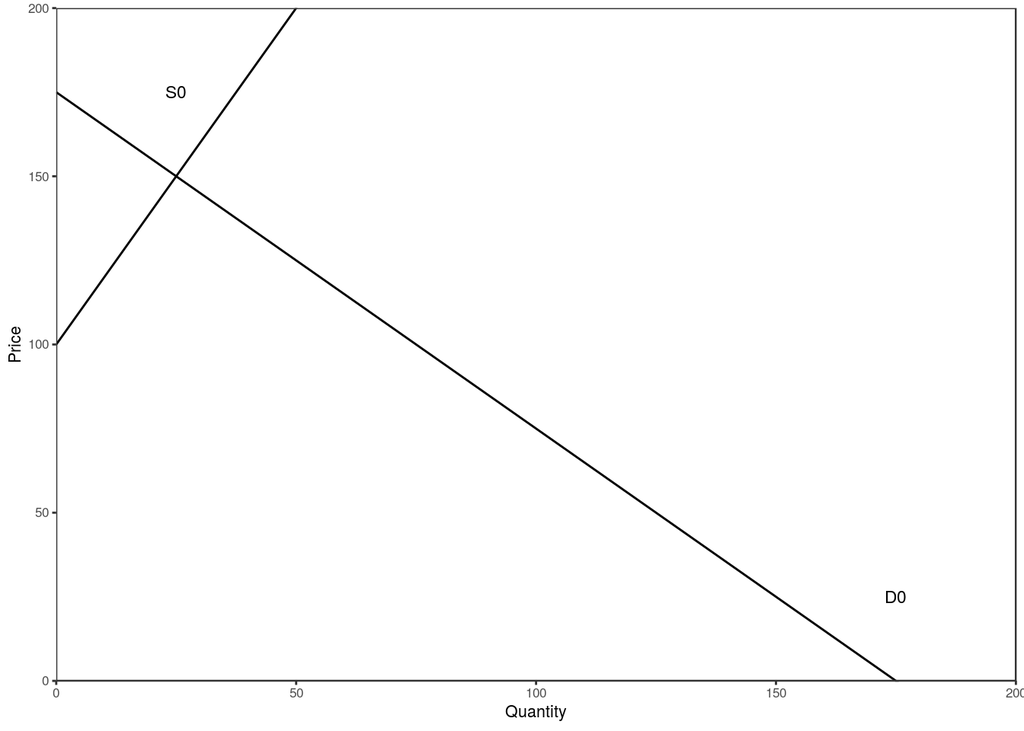

```r
ggplot()+ #set up plot space
  theme_bw(base_size=8)+ #black and white theme
  theme(panel.grid.major = element_blank(), panel.grid.minor = element_blank())+ #remove grid lines
  scale_x_continuous(name = "Quantity", limits=c(0,200), expand=c(0,0)) +  #set up x-axis
  scale_y_continuous(name = "Price", limits=c(0,200), expand=c(0,0))+ #set up y-axis
  geom_abline(slope = -1, intercept = 175)+ ## demand curve
  geom_abline(slope = 2, intercept = 100)+ ## supply curve
  annotate("text", x = 175, y = 25, label = "D0", size = 3) + ##demand curve annotation
  annotate("text", x = 25, y = 175, label = "S0", size = 3) ##supply curve annotation
```

Adding new lines is as simple as layering on new geoms. For instance, if we want to add a new supply curve that is shifted out due to an increase in production, defined as $P= 70 + 2Q^S$:

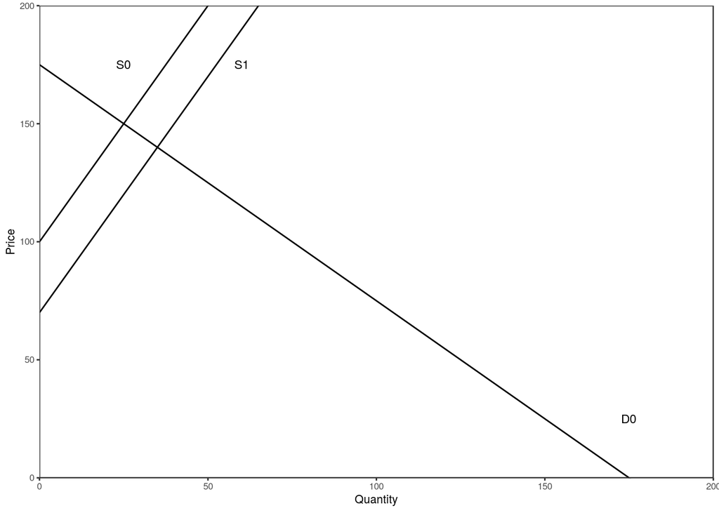

```r
ggplot()+ #set up plot space
  theme_bw(base_size=8)+ #black and white theme
  theme(panel.grid.major = element_blank(), panel.grid.minor = element_blank())+ #remove grid lines
  scale_x_continuous(name = "Quantity", limits=c(0,200), expand=c(0,0)) +  #set up x-axis
  scale_y_continuous(name = "Price", limits=c(0,200), expand=c(0,0))+ #set up y-axis
  geom_abline(slope = -1, intercept = 175)+ ## demand curve 0
  geom_abline(slope = 2, intercept = 100)+ ## supply curve 0
  geom_abline(slope = 2, intercept = 70)+ ## supply curve 1
  annotate("text", x = 175, y = 25, label = "D0", size = 3) + ##demand curve 0 annotation
  annotate("text", x = 25, y = 175, label = "S0", size = 3) + ##supply curve 0 annotation
  annotate("text", x = 60, y = 175, label = "S1", size = 3) ##supply curve 1 annotation
```

If we want to make this new supply curve look different, we can specify a `linetype` and/or a `color`:

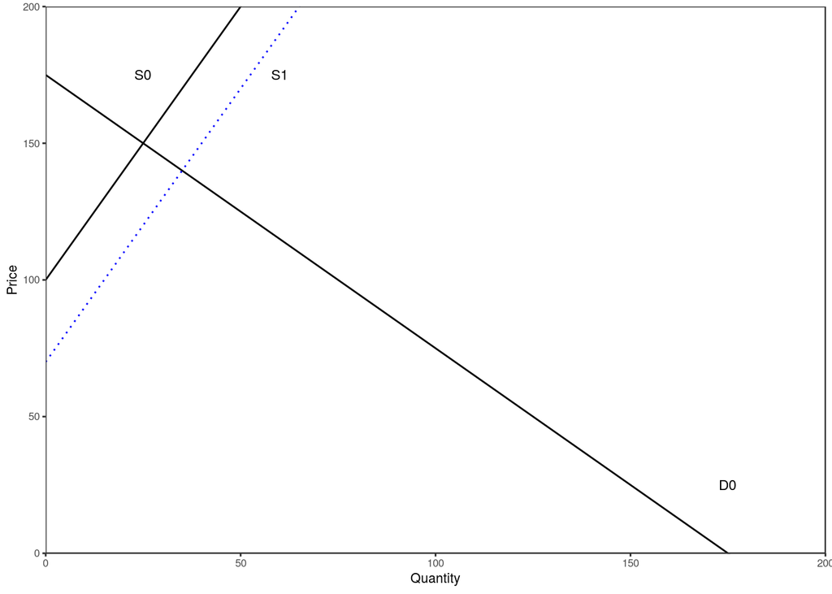

```r
ggplot()+ #set up plot space
  theme_bw(base_size=8)+ #black and white theme
  theme(panel.grid.major = element_blank(), panel.grid.minor = element_blank())+ #remove grid lines
  scale_x_continuous(name = "Quantity", limits=c(0,200), expand=c(0,0)) +  #set up x-axis
  scale_y_continuous(name = "Price", limits=c(0,200), expand=c(0,0))+ #set up y-axis
  geom_abline(slope = -1, intercept = 175)+ ## demand curve 0
  geom_abline(slope = 2, intercept = 100)+ ## supply curve 0
  geom_abline(slope = 2, intercept = 70, linetype = "dotted", color = "blue")+ ## supply curve 1
  annotate("text", x = 175, y = 25, label = "D0", size = 3) + ##demand curve 0 annotation
  annotate("text", x = 25, y = 175, label = "S0", size = 3) + ##supply curve 0 annotation
  annotate("text", x = 60, y = 175, label = "S1", size = 3) ##supply curve 1 annotation
```

Two nots about colors and line types:

1. Changing the color of lines/borders involves changing the `color` parameter. Changing the color of bars and regions involves changing the `fill` parameter. If you try to use `color` to change the color of a bar or region, only the border will change colors.
2. A list of R colors can be found [here](https://www.nceas.ucsb.edu/~frazier/RSpatialGuides/colorPaletteCheatsheet.pdf). A list of R line types can be found [here](http://www.cookbook-r.com/Graphs/Shapes_and_line_types/)

### Line Segments (Equilibrium Values and Tax Regions)

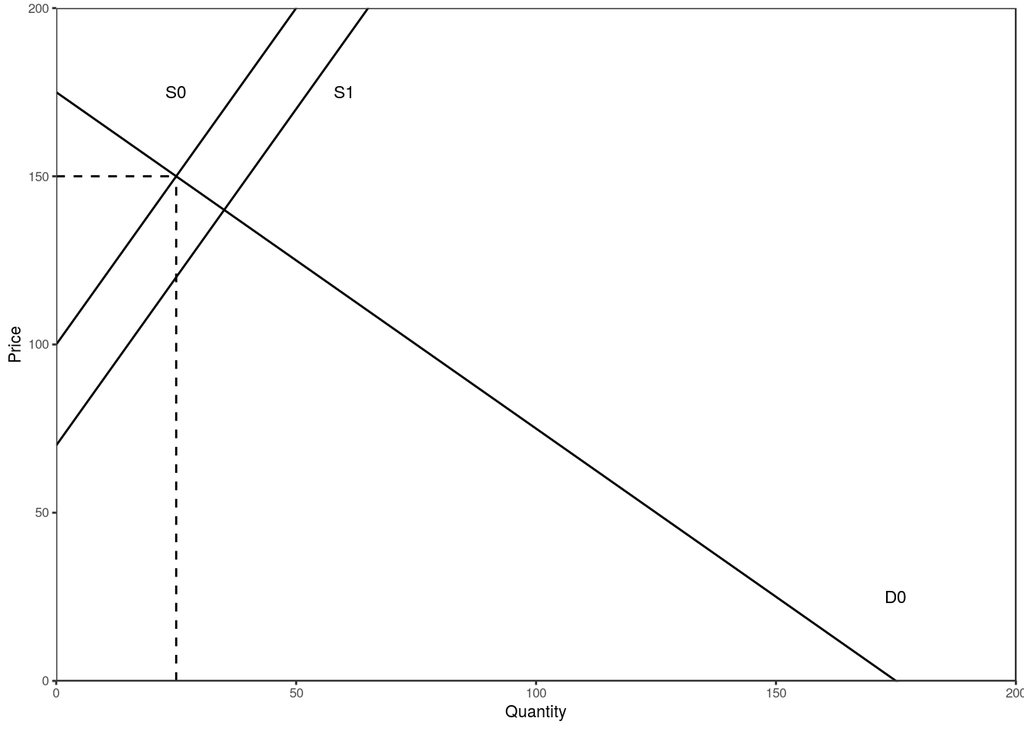

```r
ggplot()+ #set up plot space
  theme_bw(base_size=8)+ #black and white theme
  theme(panel.grid.major = element_blank(), panel.grid.minor = element_blank())+ #remove grid lines
  scale_x_continuous(name = "Quantity", limits=c(0,200), expand=c(0,0)) +  #set up x-axis
  scale_y_continuous(name = "Price", limits=c(0,200), expand=c(0,0))+ #set up y-axis
  geom_abline(slope = -1, intercept = 175)+ ## demand curve 0
  geom_abline(slope = 2, intercept = 100)+ ## supply curve 0
  geom_abline(slope = 2, intercept = 70)+ ## supply curve 1
  annotate("text", x = 175, y = 25, label = "D0", size = 3) + ##demand curve 0 annotation
  annotate("text", x = 25, y = 175, label = "S0", size = 3) + ##supply curve 0 annotation
  annotate("text", x = 60, y = 175, label = "S1", size = 3) + ##supply curve 1 annotation
  geom_segment(aes(x=25 , xend=25, y=0, yend=150), linetype = "dashed")+ ## equilibrium quantity 0
  geom_segment(aes(x=0 , xend=25, y=150, yend=150), linetype = "dashed") ## equlibrium price 0
```

For the vertical line, depicting the equilibrium quantity, we want the x value to be fixed, therefore both `x` and `xend` = 25, but we want the y to range from the origin `y=0` to the equilibrium point `yend=150`. The same logic is applied to drawing the horizontal price line.

### Shaded Areas (Total Value)

What if we want to shade in certain areas? This can be done using the `geom_rect` layer for rectangles or the more generic `geom_ribbon` layer any shape. Returning to the homework questions, what happens if we impose a 30 dollar tax on each unit? We can use the line segments above to denote the tax region and the post-tax equilibrium quantity.

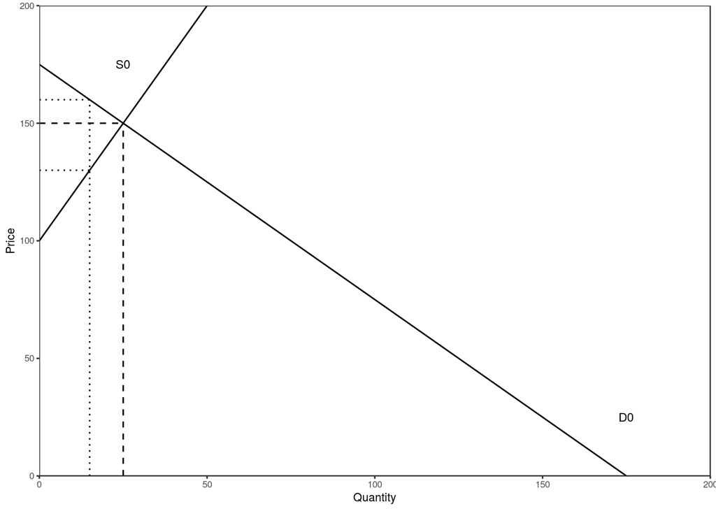

```r
ggplot()+
  theme_bw(base_size=8)+ #black and white theme
  theme(panel.grid.major = element_blank(), panel.grid.minor = element_blank())+ #remove grid lines
  scale_x_continuous(name = "Quantity", limits=c(0,200), expand=c(0,0)) +  #set up x-axis
  scale_y_continuous(name = "Price", limits=c(0,200), expand=c(0,0))+ #set up y-axis
  geom_abline(slope = -1, intercept = 175)+ ## demand curve 0
  geom_abline(slope = 2, intercept = 100)+ ## supply curve 0
  annotate("text", x = 175, y = 25, label = "D0", size = 3) + ##demand curve 0 annotation
  annotate("text", x = 25, y = 175, label = "S0", size = 3) + ##supply curve 0 annotation
  geom_segment(aes(x=25 , xend=25, y=0, yend=150), linetype = "dashed")+ ## equilibrium quantity 0
  geom_segment(aes(x=0 , xend=25, y=150, yend=150), linetype = "dashed")+ ## equlibrium price 0
  geom_segment(aes(x=0 , xend=15, y=130, yend=130), linetype = "dotted")+ ## sellers price
  geom_segment(aes(x=0 , xend=15, y=160, yend=160), linetype = "dotted")+ ## buyers price
  geom_segment(aes(x=15 , xend=15, y=0, yend=160), linetype = "dotted") ## equilibrium quantity + tax
```

If we want to shade in the rectangular region that represents tax revenue, we can use the `geom_rect` layer:

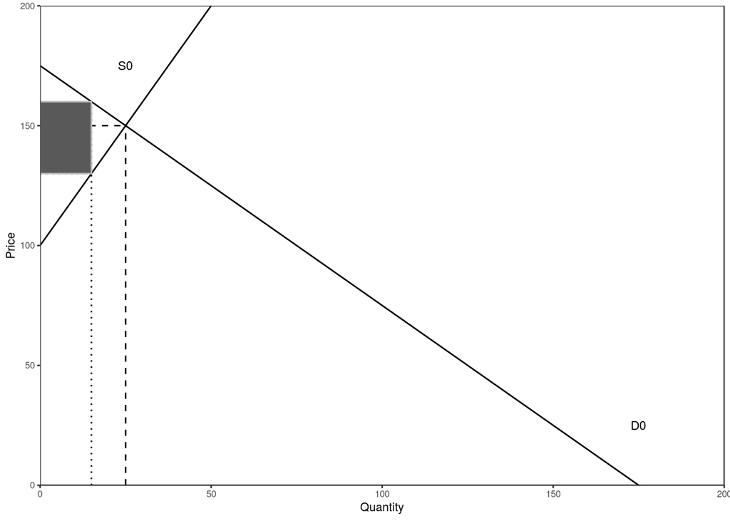

```r
ggplot()+
  theme_bw(base_size=8)+ #black and white theme
  theme(panel.grid.major = element_blank(), panel.grid.minor = element_blank())+ #remove grid lines
  scale_x_continuous(name = "Quantity", limits=c(0,200), expand=c(0,0)) +  #set up x-axis
  scale_y_continuous(name = "Price", limits=c(0,200), expand=c(0,0))+ #set up y-axis
  geom_abline(slope = -1, intercept = 175)+ ## demand curve 0
  geom_abline(slope = 2, intercept = 100)+ ## supply curve 0
  annotate("text", x = 175, y = 25, label = "D0", size = 3) + ##demand curve 0 annotation
  annotate("text", x = 25, y = 175, label = "S0", size = 3) + ##supply curve 0 annotation
  geom_segment(aes(x=25 , xend=25, y=0, yend=150), linetype = "dashed")+ ## equilibrium quantity 0
  geom_segment(aes(x=0 , xend=25, y=150, yend=150), linetype = "dashed")+ ## equlibrium price 0
  geom_segment(aes(x=0 , xend=15, y=130, yend=130), linetype = "dotted")+ ## sellers price
  geom_segment(aes(x=0 , xend=15, y=160, yend=160), linetype = "dotted")+ ## buyers price
  geom_segment(aes(x=15 , xend=15, y=0, yend=160), linetype = "dotted")+ ## equilibrium quantity + tax
  geom_rect(aes(xmin=0,xmax=15,ymin=130,ymax=160), color ="gray") ## tax revenue
```

Here we see that the order of our layers matters. Because `geom_rect` is the last layer it sits on top of everything below it. If we wanted the underlying lines to show through, we can move `geom_rect` earlier in layer order:

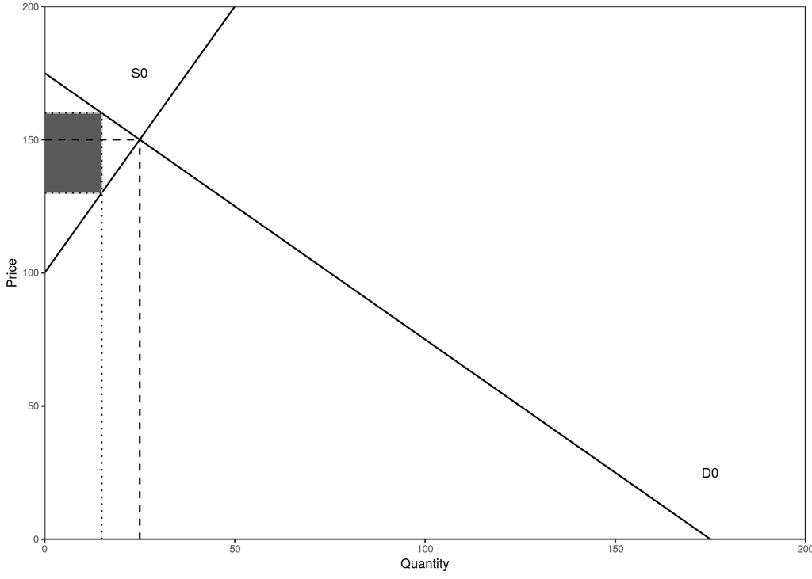

```r
ggplot()+
  theme_bw(base_size=8)+ #black and white theme
  theme(panel.grid.major = element_blank(), panel.grid.minor = element_blank())+ #remove grid lines
  scale_x_continuous(name = "Quantity", limits=c(0,200), expand=c(0,0)) +  #set up x-axis
  scale_y_continuous(name = "Price", limits=c(0,200), expand=c(0,0))+ #set up y-axis
  geom_abline(slope = -1, intercept = 175)+ ## demand curve 0
  geom_abline(slope = 2, intercept = 100)+ ## supply curve 0
  annotate("text", x = 175, y = 25, label = "D0", size = 3) + ##demand curve 0 annotation
  annotate("text", x = 25, y = 175, label = "S0", size = 3) + ##supply curve 0 annotation
  geom_rect(aes(xmin=0,xmax=15,ymin=130,ymax=160), color ="gray") + ##tax revenue
  geom_segment(aes(x=25 , xend=25, y=0, yend=150), linetype = "dashed")+ ## equilibrium quantity 0
  geom_segment(aes(x=0 , xend=25, y=150, yend=150), linetype = "dashed")+ ## equlibrium price 0
  geom_segment(aes(x=0 , xend=15, y=130, yend=130), linetype = "dotted")+ ## sellers price
  geom_segment(aes(x=0 , xend=15, y=160, yend=160), linetype = "dotted")+ ## buyers price
  geom_segment(aes(x=15 , xend=15, y=0, yend=160), linetype = "dotted") ## equilibrium quantity + tax
```

Or, if wes simply want to adjust the transparency of the shaded region, we can adjust the `alpha` parameter, which permits values ranging from 0 (see-through) to 1 (opaque)

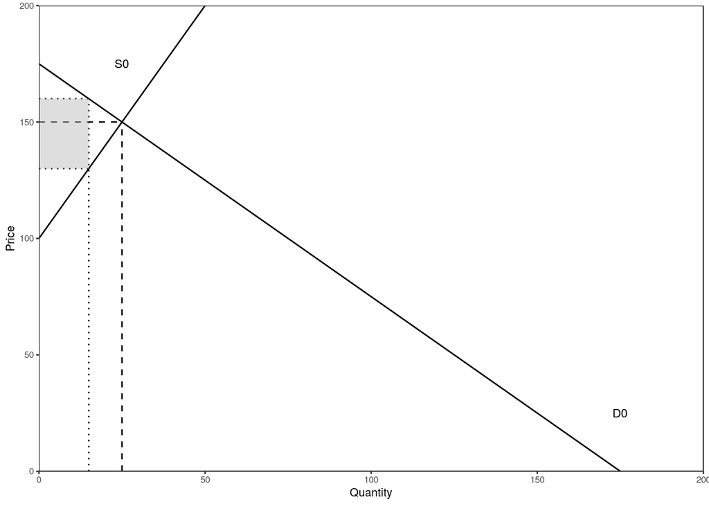

```r
ggplot()+
  theme_bw(base_size=8)+ #black and white theme
  theme(panel.grid.major = element_blank(), panel.grid.minor = element_blank())+ #remove grid lines
  scale_x_continuous(name = "Quantity", limits=c(0,200), expand=c(0,0)) +  #set up x-axis
  scale_y_continuous(name = "Price", limits=c(0,200), expand=c(0,0))+ #set up y-axis
  geom_abline(slope = -1, intercept = 175)+ ## demand curve 0
  geom_abline(slope = 2, intercept = 100)+ ## supply curve 0
  annotate("text", x = 175, y = 25, label = "D0", size = 3) + ##demand curve 0 annotation
  annotate("text", x = 25, y = 175, label = "S0", size = 3) + ##supply curve 0 annotation
  geom_segment(aes(x=25 , xend=25, y=0, yend=150), linetype = "dashed")+ ## equilibrium quantity 0
  geom_segment(aes(x=0 , xend=25, y=150, yend=150), linetype = "dashed")+ ## equlibrium price 0
  geom_segment(aes(x=0 , xend=15, y=130, yend=130), linetype = "dotted")+ ## sellers price
  geom_segment(aes(x=0 , xend=15, y=160, yend=160), linetype = "dotted")+ ## buyers price
  geom_segment(aes(x=15 , xend=15, y=0, yend=160), linetype = "dotted")+ ## equilibrium quantity + tax
  geom_rect(aes(xmin=0,xmax=15,ymin=130,ymax=160), fill ="gray", alpha = .5) ## tax revenue
```

Instead of shading in the tax revenue region, what if we want to instead shade in the triangular region representing deadweight loss? Shading in non-rectangular regions is somewhat more difficult and requires the use of the more flexible, but less intuitive, `geom_ribbon` layer.

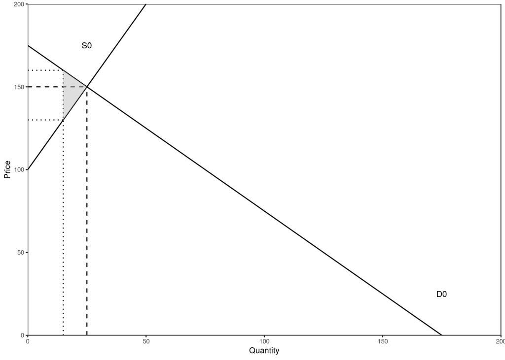

```r
ggplot()+
  theme_bw(base_size=8)+ #black and white theme
  theme(panel.grid.major = element_blank(), panel.grid.minor = element_blank())+ #remove grid lines
  scale_x_continuous(name = "Quantity", limits=c(0,200), expand=c(0,0)) +  #set up x-axis
  scale_y_continuous(name = "Price", limits=c(0,200), expand=c(0,0))+ #set up y-axis
  geom_abline(slope = -1, intercept = 175)+ ## demand curve 0
  geom_abline(slope = 2, intercept = 100)+ ## supply curve 0
  annotate("text", x = 175, y = 25, label = "D0", size = 3) + ##demand curve 0 annotation
  annotate("text", x = 25, y = 175, label = "S0", size = 3) + ##supply curve 0 annotation
  geom_segment(aes(x=25 , xend=25, y=0, yend=150), linetype = "dashed")+ ## equilibrium quantity 0
  geom_segment(aes(x=0 , xend=25, y=150, yend=150), linetype = "dashed")+ ## equlibrium price 0
  geom_segment(aes(x=0 , xend=15, y=130, yend=130), linetype = "dotted")+ ## sellers price
  geom_segment(aes(x=0 , xend=15, y=160, yend=160), linetype = "dotted")+ ## buyers price
  geom_segment(aes(x=15 , xend=15, y=0, yend=160), linetype = "dotted")+ ## equilibrium quantity + tax
  geom_ribbon(aes(x=c(15,25),ymin=c(130,150),ymax=c(160,150)), fill="gray", alpha="0.5")
```

`geom_region` requires a span of values that are not intuitively labeled. In general, fill in the values from left to right. `x=c(15,25)` indicates that you want your shaded region to extend from x = 15 to x = 25. `ymin=c(130,150)` are the y coordinates for the lower side of the triangle to span from y = 130 to y = 150. Lastly, `ymax=c(160,150)` are the y coordinates for the upper side of the triangle to span from y = 160 to y = 150. In the case of a triangle, you can swap the values of `ymin` and `ymax` and produce the same shaded region.

#### Total Value Under Curve Example

For another example, what if we want to shade in the regions depicting the social value to an increase in supply? Returning to our plot that included the new, shifted-out supply curve, we can shade in the areas representing the two sources of social value:

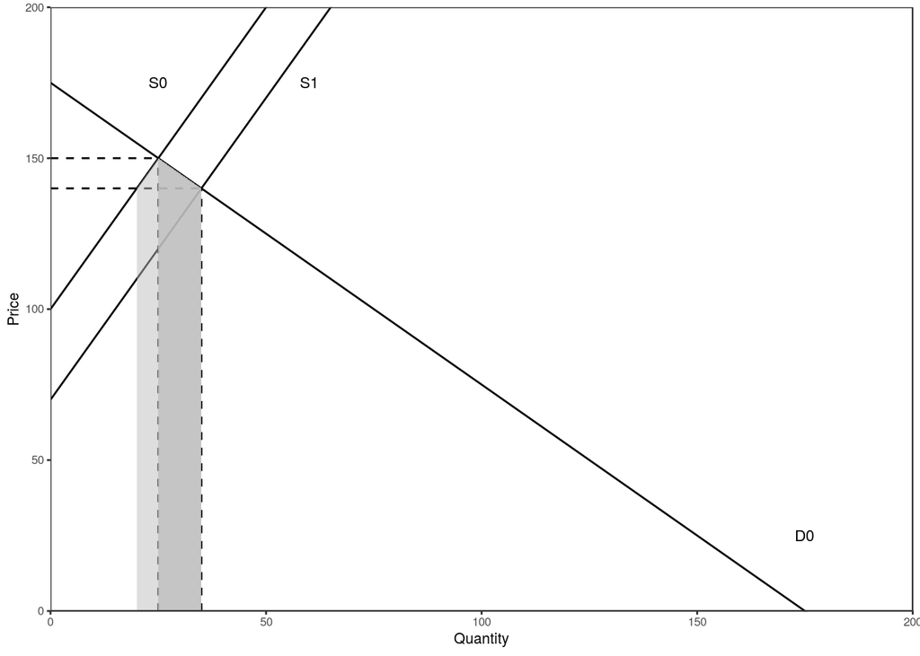

```r
ggplot()+ #set up plot space
  theme_bw(base_size=8)+ #black and white theme
  theme(panel.grid.major = element_blank(), panel.grid.minor = element_blank())+ #remove grid lines
  scale_x_continuous(name = "Quantity", limits=c(0,200), expand=c(0,0)) +  #set up x-axis
  scale_y_continuous(name = "Price", limits=c(0,200), expand=c(0,0))+ #set up y-axis
  geom_abline(slope = -1, intercept = 175)+ ## demand curve 0
  geom_abline(slope = 2, intercept = 100)+ ## supply curve 0
  geom_abline(slope = 2, intercept = 70)+ ## supply curve 1
  annotate("text", x = 175, y = 25, label = "D0", size = 3) + ##demand curve 0 annotation
  annotate("text", x = 25, y = 175, label = "S0", size = 3) + ##supply curve 0 annotation
  annotate("text", x = 60, y = 175, label = "S1", size = 3) + ##supply curve 1 annotation
  geom_segment(aes(x=25 , xend=25, y=0, yend=150), linetype = "dashed")+ ## equilibrium quantity 0
  geom_segment(aes(x=0 , xend=25, y=150, yend=150), linetype = "dashed")+ ## equlibrium price 0
  geom_segment(aes(x=35 , xend=35, y=0, yend=140), linetype = "dashed")+ ## equilibrium quantity 1
  geom_segment(aes(x=0 , xend=35, y=140, yend=140), linetype = "dashed")+ ## equlibrium price 1
  geom_ribbon(aes(x=c(20,25),ymin=0,ymax=c(140,150)), fill="gray", alpha="0.5") + ## value due to freed resources
  geom_ribbon(aes(x=c(25,35),ymin=0,ymax=c(150,140)), fill="gray", alpha="0.9") ## value due to increased production
```

The value of freed resources (the lighter gray region) is a shaded region running from x= 20 (left) to x = 25 (right), a minimum y ranging from y = 0 (left) to y = 0 (right) and a maximum y ranging from y = 140 (left) to y = 150 (right). The same logic applies to the region depicting value of increased quantity (the darker gray region), only now, the maximum y ranges from y = 150 (left) to y = 140 (right).

## Exporting Plots

Once you’ve created your graph, how do you export it? The easiest option would be to screenshot the graph, but the image quality can be low. Above the “Plots” pane of RStudio, there is an “Export” button that works but I have found it to work inconsistently. The best option is to incorpporate a line of code that exports it for you, giving you a full range of export options. Taking our last graph, we can use the command `ggsave` to produce a pdf called “totalvalue.pdf”.

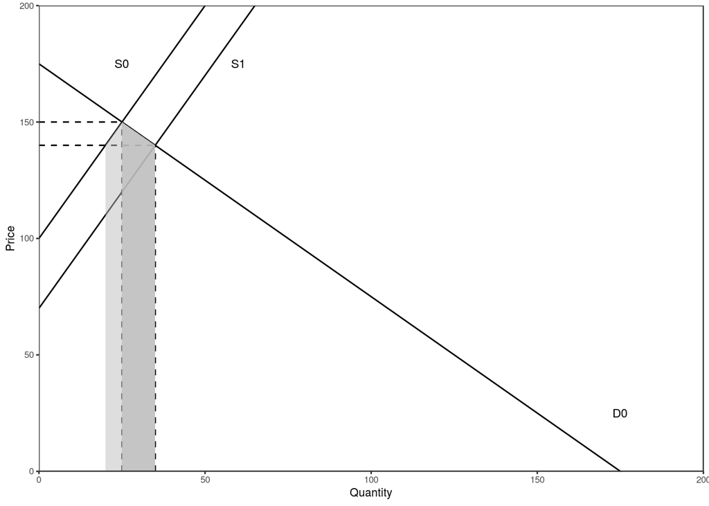

```r
# set working directory
setwd("~/projects")

ggplot()+ #set up plot space
  theme_bw(base_size=8)+ #black and white theme
  theme(panel.grid.major = element_blank(), panel.grid.minor = element_blank())+ #remove grid lines
  scale_x_continuous(name = "Quantity", limits=c(0,200), expand=c(0,0)) +  #set up x-axis
  scale_y_continuous(name = "Price", limits=c(0,200), expand=c(0,0))+ #set up y-axis
  geom_abline(slope = -1, intercept = 175)+ ## demand curve 0
  geom_abline(slope = 2, intercept = 100)+ ## supply curve 0
  geom_abline(slope = 2, intercept = 70)+ ## supply curve 1
  annotate("text", x = 175, y = 25, label = "D0", size = 3) + ##demand curve 0 annotation
  annotate("text", x = 25, y = 175, label = "S0", size = 3) + ##supply curve 0 annotation
  annotate("text", x = 60, y = 175, label = "S1", size = 3) + ##supply curve 1 annotation
  geom_segment(aes(x=25 , xend=25, y=0, yend=150), linetype = "dashed")+ ## equilibrium quantity 0
  geom_segment(aes(x=0 , xend=25, y=150, yend=150), linetype = "dashed")+ ## equlibrium price 0
  geom_segment(aes(x=35 , xend=35, y=0, yend=140), linetype = "dashed")+ ## equilibrium quantity 1
  geom_segment(aes(x=0 , xend=35, y=140, yend=140), linetype = "dashed")+ ## equlibrium price 1
  geom_ribbon(aes(x=c(20,25),ymin=0,ymax=c(140,150)), fill="gray", alpha="0.5") + ## value due to freed resources
  geom_ribbon(aes(x=c(25,35),ymin=0,ymax=c(150,140)), fill="gray", alpha="0.9") ## value due to increased production
```

```r
### Save this plot
ggsave(filename = "totalvalue.pdf")
```

`ggsave` has smart defaults and only requires 1 parameter, `filename`, which provides the name and format of the exported image. By default, `ggsave` will export the last produced graph. If you do not want this to be the case, you need to (1) name your plots using the `<-` operator and (2) specify the `plot` parameter.

```r
myplot <- ggplot()+ #set up plot space
  theme_bw(base_size=8)+ #black and white theme
  theme(panel.grid.major = element_blank(), panel.grid.minor = element_blank())+ #remove grid lines
  scale_x_continuous(name = "Quantity", limits=c(0,200), expand=c(0,0)) +  #set up x-axis
  scale_y_continuous(name = "Price", limits=c(0,200), expand=c(0,0))+ #set up y-axis
  geom_abline(slope = -1, intercept = 175)+ ## demand curve 0
  geom_abline(slope = 2, intercept = 100)+ ## supply curve 0
  geom_abline(slope = 2, intercept = 70)+ ## supply curve 1
  annotate("text", x = 175, y = 25, label = "D0", size = 3) + ##demand curve 0 annotation
  annotate("text", x = 25, y = 175, label = "S0", size = 3) + ##supply curve 0 annotation
  annotate("text", x = 60, y = 175, label = "S1", size = 3) + ##supply curve 1 annotation
  geom_segment(aes(x=25 , xend=25, y=0, yend=150), linetype = "dashed")+ ## equilibrium quantity 0
  geom_segment(aes(x=0 , xend=25, y=150, yend=150), linetype = "dashed")+ ## equlibrium price 0
  geom_segment(aes(x=35 , xend=35, y=0, yend=140), linetype = "dashed")+ ## equilibrium quantity 1
  geom_segment(aes(x=0 , xend=35, y=140, yend=140), linetype = "dashed")+ ## equlibrium price 1
  geom_ribbon(aes(x=c(20,25),ymin=0,ymax=c(140,150)), fill="gray", alpha="0.5") + ## value due to freed resources
  geom_ribbon(aes(x=c(25,35),ymin=0,ymax=c(150,140)), fill="gray", alpha="0.9") ## value due to increased production

### Save this plot
setwd("~/projects")
ggsave(filename = "totalvalue.pdf", plot = myplot)
```

`ggsave` will try to export a plot that resembles the size of the plot in your RStudio “Plots” pane. If you make the pane bigger and re-run the `ggsave` command, it will make a bigger plot. If you would rather manually specify the size of the exported plot, you can fill out the `height` and `width` parameters:

```r
ggsave(filename = "totalvalue_1.pdf", plot = myplot, height = 8, width = 8)
```

One very annoying thing about changing the size of the figure on export is that text will not change proportionally. Therefore, you will need to play with the text size of your plot in order for it to be sized appropriately on the exported image.

## Conclusion

The various graphs above, along with some dedictated Google searching, should be enough to provide a recipe for producing basic supply and demand graphs.